# Practical Machine Learning

This is the write-up for the Practical Machine Learning project, data source: http://groupware.les.inf.puc-rio.br/har. This is a problem of classification. I chose to use randomForest since it corrects for decision trees overfitting to their training set.

Add libraries and read training and testing data.

```r
library(caret)
library(randomForest)
training <- read.csv("pml-training.csv", header = TRUE, sep = ",", quote = "\"", dec = ".", fill = TRUE, comment.char = "")
testing <- read.csv("pml-testing.csv", header = TRUE, sep = ",", quote = "\"", dec = ".", fill = TRUE, comment.char = "")
```

Clean data. I removed the columns which contain too many rows of NA and empty. I also removed predictors that I don’t think useful, like timestamp.

```r
# Remove NA columns
training2 <- training[, colSums(is.na(training)) != 19216]
# Remove empty columns
newtraining <- training2[, colSums(training2 == "") != 19216]
newtraining$cvtd_timestamp <- NULL
newtraining$raw_timestamp_part_1 <- NULL
newtraining$raw_timestamp_part_2 <- NULL
newtraining$user_name <- NULL
```

Split taining data into my trainig data and my testing data, in order to do cross validation and calculate the accuracy of my model later.

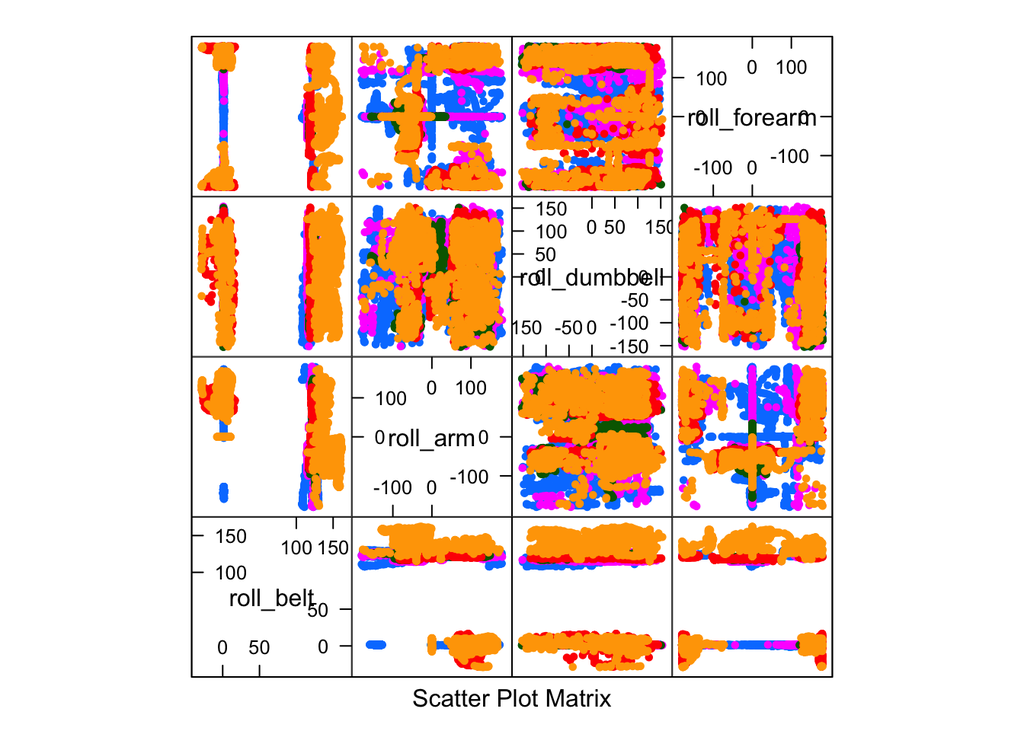

```r
inTrain = createDataPartition(newtraining$classe, p = 3/4)[[1]]
mytraining1 = newtraining[ inTrain,]
mytesting1 = newtraining[-inTrain,]
# Remove index
mytraining1$X <- NULL
mytesting1$X <- NULL
# Exploratory plot sample using roll predictors
samplesdata <- mytraining1[grep("^roll", colnames(mytraining1))]
featurePlot(x = samplesdata, y = mytraining1$classe, pch = 20, plot = "pairs")
```

Let the final testing data frame has the same columns as the training data frame, except for the “classe”

```r
mytraining2=mytraining1
mytraining2$classe <- NULL
coltest <- colnames(mytraining2)
print(coltest) # These are the predictors in my following model
```

```
##  [1] "new_window"           "num_window"           "roll_belt"
##  [4] "pitch_belt"           "yaw_belt"             "total_accel_belt"
##  [7] "gyros_belt_x"         "gyros_belt_y"         "gyros_belt_z"
## [10] "accel_belt_x"         "accel_belt_y"         "accel_belt_z"
## [13] "magnet_belt_x"        "magnet_belt_y"        "magnet_belt_z"
## [16] "roll_arm"             "pitch_arm"            "yaw_arm"
## [19] "total_accel_arm"      "gyros_arm_x"          "gyros_arm_y"
## [22] "gyros_arm_z"          "accel_arm_x"          "accel_arm_y"
## [25] "accel_arm_z"          "magnet_arm_x"         "magnet_arm_y"
## [28] "magnet_arm_z"         "roll_dumbbell"        "pitch_dumbbell"
## [31] "yaw_dumbbell"         "total_accel_dumbbell" "gyros_dumbbell_x"
## [34] "gyros_dumbbell_y"     "gyros_dumbbell_z"     "accel_dumbbell_x"
## [37] "accel_dumbbell_y"     "accel_dumbbell_z"     "magnet_dumbbell_x"
## [40] "magnet_dumbbell_y"    "magnet_dumbbell_z"    "roll_forearm"
## [43] "pitch_forearm"        "yaw_forearm"          "total_accel_forearm"
## [46] "gyros_forearm_x"      "gyros_forearm_y"      "gyros_forearm_z"
## [49] "accel_forearm_x"      "accel_forearm_y"      "accel_forearm_z"
## [52] "magnet_forearm_x"     "magnet_forearm_y"     "magnet_forearm_z"
```

```r
testing1 <- testing[coltest]
```

The class(type) of each predictor are diffirent from mytraining data and final testing data. In order to make them have the same types, I combined them first and then remove the newly combined useless rows.

```r
# run these two lines can see the different classes
# lapply(mytraining1, class)
# lapply(testing1, class)
testing1 <- rbind(testing1, mytraining2) # combine
testing1 <- head(testing1,-14718) # remove
```

Train the model, test the model and predict. At first, I used caret rf method to train my model, but it took so long (more than 4 hours on my laptop), so I finally used the basic randomForest package.

```r
# train
modFit1 <- randomForest(classe ~. ,data=mytraining1, keep.forest=TRUE, importance=TRUE)
modFit1
```

```
##
## Call:
##  randomForest(formula = classe ~ ., data = mytraining1, keep.forest = TRUE,      importance = TRUE)
##                Type of random forest: classification
##                      Number of trees: 500
## No. of variables tried at each split: 7
##
##         OOB estimate of  error rate: 0.33%
## Confusion matrix:
##      A    B    C    D    E  class.error
## A 4184    1    0    0    0 0.0002389486
## B   10 2837    1    0    0 0.0038623596
## C    0   11 2555    1    0 0.0046747176
## D    0    0   18 2392    2 0.0082918740
## E    0    0    0    4 2702 0.0014781966
```

```r
# test
predict1 <- predict(modFit1, mytesting1)
# see the accuracy
confusionMatrix(predict1, mytesting1$classe)
```

```
## Confusion Matrix and Statistics
##
##           Reference
## Prediction    A    B    C    D    E
##          A 1394    4    0    0    0
##          B    1  943    2    0    0
##          C    0    2  853    5    0
##          D    0    0    0  799    0
##          E    0    0    0    0  901
##
## Overall Statistics
##
##                Accuracy : 0.9971
##                  95% CI : (0.9952, 0.9984)
##     No Information Rate : 0.2845
##     P-Value [Acc > NIR] : < 2.2e-16
##
##                   Kappa : 0.9964
##  Mcnemar's Test P-Value : NA
##
## Statistics by Class:
##
##                      Class: A Class: B Class: C Class: D Class: E
## Sensitivity            0.9993   0.9937   0.9977   0.9938   1.0000
## Specificity            0.9989   0.9992   0.9983   1.0000   1.0000
## Pos Pred Value         0.9971   0.9968   0.9919   1.0000   1.0000
## Neg Pred Value         0.9997   0.9985   0.9995   0.9988   1.0000
## Prevalence             0.2845   0.1935   0.1743   0.1639   0.1837
## Detection Rate         0.2843   0.1923   0.1739   0.1629   0.1837
## Detection Prevalence   0.2851   0.1929   0.1754   0.1629   0.1837
## Balanced Accuracy      0.9991   0.9965   0.9980   0.9969   1.0000
```

```r
# predict
predict2 <- predict(modFit1, testing1)
# outcome
predict2
```

```
##  1  2  3  4  5  6  7  8  9 10 11 12 13 14 15 16 17 18 19 20
##  B  A  B  A  A  E  D  B  A  A  B  C  B  A  E  E  A  B  B  B
## Levels: A B C D E
```

```r
# Calculate out of sample error appropriately with cross-validation
corret = 0
for (i in 1:length(predict1)) {
  if (predict1[i] == mytesting1$classe[i]) {
    corret = corret+1
  }
}
outaccuracy <- corret/length(predict1)
error <- (1-outaccuracy)*100
cat("out of sample error: ",error,"%")
```

```
## out of sample error:  0.2854812 %
```

Different plots.

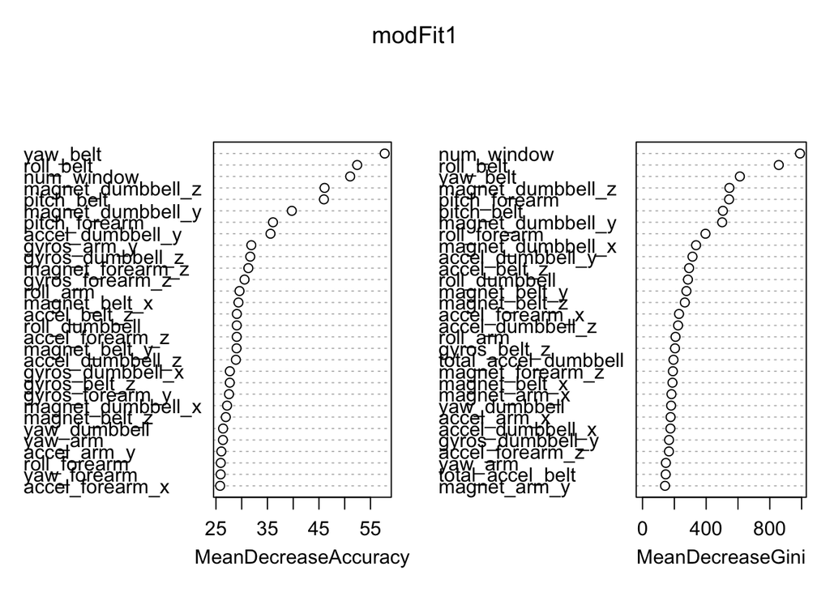

```r
# Importance of each predictor
varImpPlot(modFit1)
```

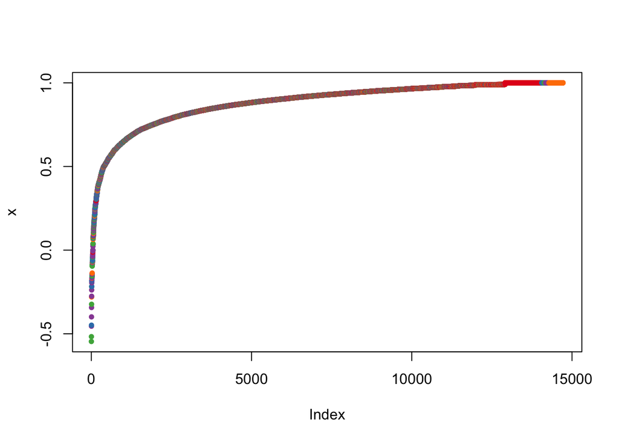

```r
# Under majority votes, positive margin means correct classification, and negative means wrong classification. In the 14718 cases, few are negative margin, which means the big majority are classified correctly.
plot(margin(modFit1))
```

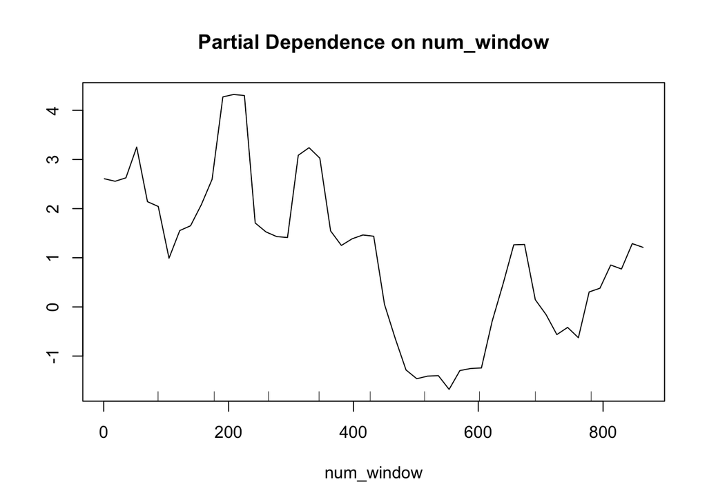

```r
# This a graphical depiction of the marginal effect of num_window (the most important predictor) on the class probability (classification)
partialPlot(modFit1, mytraining1, num_window)
```

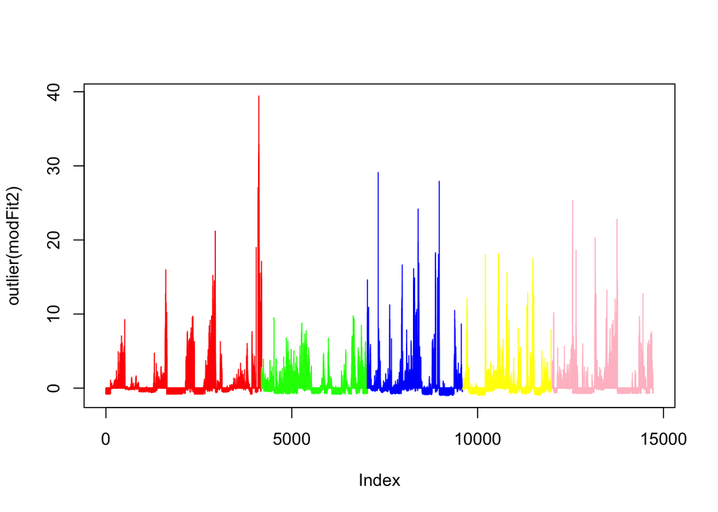

```r
# Compute outlying measures based on the proximity matrix, we can see the green class has smallest number of outliers
modFit2 <- randomForest(classe~.,data=mytraining1, proximity=TRUE)
plot(outlier(modFit2), type="h", col=c("red", "green", "blue", "yellow", "pink")[as.numeric(mytraining1$classe)])
```

```r
# It took me very very long to plot the scaling coordinates of the proximity matrix from randomForest, and my laptop crushed, so I gave up to the next plot
# MDSplot(modFit2, mytraining1$classe)
```

I also tried to do PCA first and try to make the predictors to be more reasonalble. The accuracy was good but not better than the above pure predictors. I finally kept the above method.

```r
# PCA
preProc1 <- preProcess(newtraining, method='pca', thresh=0.99, outcome=newtraining$classe) # default is 0.95
# preProc1$rotation
trainPC1 = predict(preProc1, newtraining)

inTrain = createDataPartition(trainPC1$classe, p = 3/4)[[1]]
mytrainPC1 = trainPC1[ inTrain,]
mytestPC1 = trainPC1[-inTrain,]

modFit3 <- randomForest(classe ~. , data=mytrainPC1)
modFit3
```

```
##
## Call:
##  randomForest(formula = classe ~ ., data = mytrainPC1)
##                Type of random forest: classification
##                      Number of trees: 500
## No. of variables tried at each split: 6
##
##         OOB estimate of  error rate: 0.75%
## Confusion matrix:
##      A    B    C    D    E  class.error
## A 4181    3    0    0    1 0.0009557945
## B   20 2817   11    0    0 0.0108848315
## C    0   17 2542    8    0 0.0097389949
## D    0    0   36 2370    6 0.0174129353
## E    0    2    0    6 2698 0.0029563932
```

```r
predict3 <- predict(modFit3, mytestPC1)
confusionMatrix(predict3, mytestPC1$classe)
```

```
## Confusion Matrix and Statistics
##
##           Reference
## Prediction    A    B    C    D    E
##          A 1395    3    0    0    0
##          B    0  943    4    0    0
##          C    0    3  846   12    0
##          D    0    0    5  789    1
##          E    0    0    0    3  900
##
## Overall Statistics
##
##                Accuracy : 0.9937
##                  95% CI : (0.991, 0.9957)
##     No Information Rate : 0.2845
##     P-Value [Acc > NIR] : < 2.2e-16
##
##                   Kappa : 0.992
##  Mcnemar's Test P-Value : NA
##
## Statistics by Class:
##
##                      Class: A Class: B Class: C Class: D Class: E
## Sensitivity            1.0000   0.9937   0.9895   0.9813   0.9989
## Specificity            0.9991   0.9990   0.9963   0.9985   0.9993
## Pos Pred Value         0.9979   0.9958   0.9826   0.9925   0.9967
## Neg Pred Value         1.0000   0.9985   0.9978   0.9963   0.9998
## Prevalence             0.2845   0.1935   0.1743   0.1639   0.1837
## Detection Rate         0.2845   0.1923   0.1725   0.1609   0.1835
## Detection Prevalence   0.2851   0.1931   0.1756   0.1621   0.1841
## Balanced Accuracy      0.9996   0.9963   0.9929   0.9899   0.9991
```